# What Do Our Daily Food and Drink Choices Tell Us?

## About this data story

This visual data story explores daily food and drink consumption patterns recorded through an observational logging Google Form. Each observation captures what was consumed, where it came from, how long the eating occasion took, and how satisfied the person felt afterwards. Data was collected across multiple days in 2026, resulting in a total of 46 observations.

## What types of food and drink were consumed?

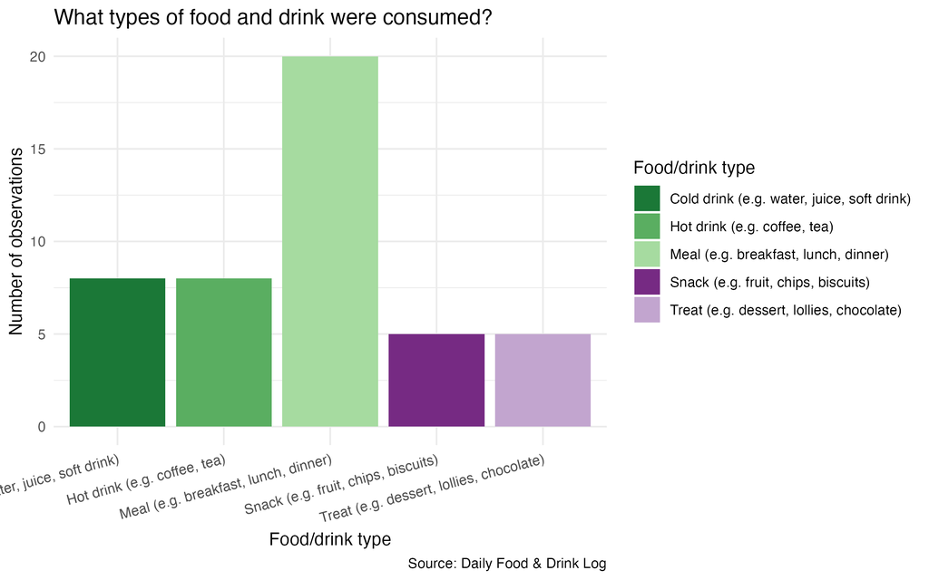

Meals such as breakfast, lunch, and dinner made up the largest proportion of observations, accounting for 20 out of 46 recorded occasions. Hot drinks and cold drinks were equally common, each appearing 8 times. Snacks and treats were the least frequent, which suggests that most eating occasions were structured meals rather than informal snacking.

## Does where food comes from affect satisfaction?

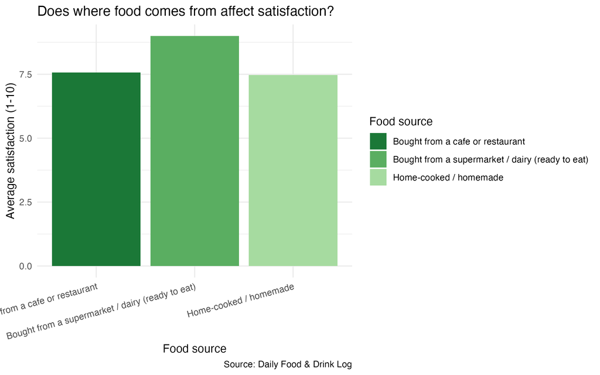

Interestingly, food bought from a supermarket or dairy had the highest average satisfaction score, slightly above food from cafes or restraunts and home-cooked meals. The differences are relatively small, which suggests that satisfaction may depend more on personal preference than on where the food came from.

## How did recording patterns change over time?

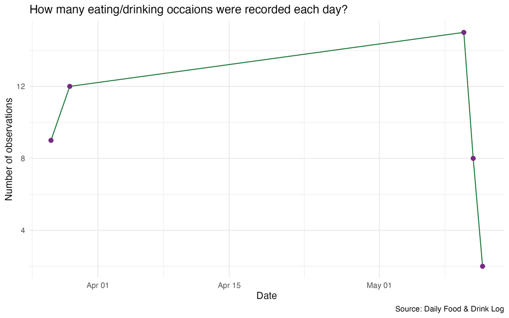

The number of eating and drinking occasions recorded varied across the data collection period from late March to mid-May 2026. Recording activity was highest in early May, with one day reaching 15 observations. The drop towards mid-May reflects the end of the collection period. This plot uses the timestamp from the logged data, converted using lubridate functions, to track how recording behaviour changed over time.